# Optional Paper Extensions for Fan Token Analysis

FRAM group project; adapted from Gian Luca Vriz and Luigi Grossi

# 1 Libraries and provenance

This is the optional monthly/weekly and forecasting profile. The submitted report’s default daily analysis is in `Code.Rmd` and `Results/Report-aligned/`. Google Trends and financial stress are outside that submitted project scope.

This notebook follows the original repository’s R Markdown format. Its modular R source files are in `R/`; the complete original notebook, data, and MIT license are preserved in `../Original-paper/`. All analysis below is performed by R.

The frozen project sample contains 20 fan tokens and Bitcoin, Ethereum, and Chiliz benchmarks, with a daily cutoff of 19 September 2026. The analytical monthly sample ends in August 2026, the last complete month. Partial final weeks are also omitted. No live market-data request is needed to reproduce results.

```r
data.frame(package = names(package_versions), version = unname(package_versions))
```

```
##    package version
## 1   exuber   1.1.0
## 2      cpm     2.3
## 3     bsts  0.9.11
## 4 forecast  8.24.0
## 5     urca   1.3.4
## 6     vars   1.6.1
## 7      MCS   0.1.3
## 8   multDM   1.1.5
## 9  Metrics   0.1.4
```

Set `params = list(regenerate = TRUE)` in `rmarkdown::render()` to execute every stage below. The default renders the included, validated result tables without refitting hundreds of forecasting models. `Rscript run_paper_extensions.R` is the direct command-line equivalent of a full regeneration.

# 2 Raw data and processing

`R/01_process_data.R` parses all 23 archived Yahoo chart JSON responses, recovers UTC dates, clips the sample, checks duplicates, constructs daily calendars, and calculates returns only between adjacent valid daily prices. It flags extremes without deleting them. Monthly and weekly inputs are arithmetic mean prices, matching the original paper code. The first return of each modeling block is padded with zero, as in the original notebook.

```r
data <- process_data()
```

```r
knitr::kable(read_table("Results/data_quality.csv"))
```

| asset_id | asset_type | first_valid_date | last_date | expected_days | valid_prices | missing_prices | coverage | duplicate_rows | invalid_prices | extreme_returns |
| --- | --- | --- | --- | --- | --- | --- | --- | --- | --- | --- |
| ac-milan-fan-token | fan_token | 2021-02-23 | 2026-09-19 | 2035 | 2035 | 0 | 1 | 0 | 0 | 1 |
| alpine-f1-team-fan-token | fan_token | 2022-02-21 | 2026-09-19 | 1672 | 1672 | 0 | 1 | 0 | 0 | 1 |
| argentine-football-association-fan-token | fan_token | 2021-08-10 | 2026-09-19 | 1867 | 1867 | 0 | 1 | 0 | 0 | 0 |
| arsenal-fan-token | fan_token | 2021-10-28 | 2026-09-19 | 1788 | 1788 | 0 | 1 | 0 | 0 | 0 |
| as-roma-fan-token | fan_token | 2020-06-21 | 2026-09-19 | 2282 | 2282 | 0 | 1 | 0 | 0 | 0 |
| atletico-madrid | fan_token | 2020-06-21 | 2026-09-19 | 2282 | 2282 | 0 | 1 | 0 | 0 | 0 |
| bitcoin | benchmark | 2019-01-01 | 2026-09-19 | 2819 | 2819 | 0 | 1 | 0 | 0 | 0 |
| chiliz | benchmark | 2019-07-01 | 2026-09-19 | 2638 | 2638 | 0 | 1 | 0 | 0 | 0 |
| croatian-ff-fan-token | fan_token | 2022-11-27 | 2026-09-19 | 1393 | 1393 | 0 | 1 | 0 | 0 | 0 |
| ethereum | benchmark | 2019-01-01 | 2026-09-19 | 2819 | 2819 | 0 | 1 | 0 | 0 | 0 |
| fc-barcelona-fan-token | fan_token | 2020-06-24 | 2026-09-19 | 2279 | 2279 | 0 | 1 | 0 | 0 | 0 |
| fc-porto | fan_token | 2021-11-16 | 2026-09-19 | 1769 | 1769 | 0 | 1 | 0 | 0 | 0 |
| galatasaray-fan-token | fan_token | 2020-06-08 | 2026-09-19 | 2295 | 2295 | 0 | 1 | 0 | 0 | 0 |
| inter-milan-fan-token | fan_token | 2021-09-14 | 2026-09-19 | 1832 | 1832 | 0 | 1 | 0 | 0 | 0 |
| juventus-fan-token | fan_token | 2020-04-22 | 2026-09-19 | 2342 | 2342 | 0 | 1 | 0 | 0 | 0 |
| lazio-fan-token | fan_token | 2021-10-21 | 2026-09-19 | 1795 | 1795 | 0 | 1 | 0 | 0 | 0 |
| manchester-city-fan-token | fan_token | 2021-05-26 | 2026-09-19 | 1943 | 1943 | 0 | 1 | 0 | 0 | 0 |
| napoli-fan-token | fan_token | 2022-09-02 | 2026-09-19 | 1479 | 1479 | 0 | 1 | 0 | 0 | 0 |
| og-fan-token | fan_token | 2020-06-21 | 2026-09-19 | 2282 | 2282 | 0 | 1 | 0 | 0 | 1 |
| paris-saint-germain-fan-token | fan_token | 2020-06-11 | 2026-09-19 | 2292 | 2292 | 0 | 1 | 0 | 0 | 0 |
| portugal-national-team-fan-token | fan_token | 2021-11-24 | 2026-09-19 | 1761 | 1761 | 0 | 1 | 0 | 0 | 0 |
| santos-fc-fan-token | fan_token | 2021-12-01 | 2026-09-19 | 1754 | 1754 | 0 | 1 | 0 | 0 | 0 |
| trabzonspor-fan-token | fan_token | 2020-11-10 | 2026-09-19 | 2140 | 2140 | 0 | 1 | 0 | 0 | 0 |

# 3 Detection phase

The actual paper packages are used: `exuber::radf()` on monthly price levels, `exuber::radf_mc_cv()` for 1,000 finite-sample Monte Carlo draws at seed 4, `exuber::datestamp()` for 95% episodes, and `cpm::processStream()` with the Kolmogorov-Smirnov statistic on monthly log returns. Endpoint-specific BSADF critical values are exported. Monthly ARL0 is 500; weekly ARL0 is 5,000. Startup is 20% of each block, with a floor of 20 observations. This adjustment and the explicit Monte Carlo critical values are documented in Methodology.txt.

```r
run_detection(data)
```

```r
tests <- read_table("Results/psy_test_summary.csv")
knitr::kable(tests[tests$test == "GSADF", c("asset_id", "observations", "min_window", "statistic", "critical_95", "reject_95")], digits = 4)
```

|  | asset_id | observations | min_window | statistic | critical_95 | reject_95 |
| --- | --- | --- | --- | --- | --- | --- |
| 3 | ac-milan-fan-token | 67 | 15 | 0.1335 | 1.8301 | FALSE |
| 6 | alpine-f1-team-fan-token | 55 | 13 | 0.3213 | 1.7788 | FALSE |
| 9 | argentine-football-association-fan-token | 61 | 14 | 0.2539 | 1.8301 | FALSE |
| 12 | arsenal-fan-token | 59 | 14 | -0.0517 | 1.8067 | FALSE |
| 15 | as-roma-fan-token | 75 | 16 | 0.1572 | 1.8650 | FALSE |
| 18 | atletico-madrid | 75 | 16 | 0.0648 | 1.8650 | FALSE |
| 21 | croatian-ff-fan-token | 46 | 12 | 2.5752 | 1.7705 | TRUE |
| 24 | fc-barcelona-fan-token | 75 | 16 | -0.0335 | 1.8650 | FALSE |
| 27 | fc-porto | 58 | 14 | 0.2491 | 1.8007 | FALSE |
| 30 | galatasaray-fan-token | 75 | 16 | -0.6256 | 1.8650 | FALSE |
| 33 | inter-milan-fan-token | 60 | 14 | -0.3327 | 1.8187 | FALSE |
| 36 | juventus-fan-token | 77 | 16 | 0.0388 | 1.8711 | FALSE |
| 39 | lazio-fan-token | 59 | 14 | 0.3135 | 1.8067 | FALSE |
| 42 | manchester-city-fan-token | 64 | 15 | 0.2798 | 1.8079 | FALSE |
| 45 | napoli-fan-token | 48 | 12 | 0.2482 | 1.7892 | FALSE |
| 48 | og-fan-token | 75 | 16 | 1.4131 | 1.8650 | FALSE |
| 51 | paris-saint-germain-fan-token | 75 | 16 | -0.4139 | 1.8650 | FALSE |
| 54 | portugal-national-team-fan-token | 58 | 14 | 2.6924 | 1.8007 | TRUE |
| 57 | santos-fc-fan-token | 57 | 14 | -0.0162 | 1.7788 | FALSE |
| 60 | trabzonspor-fan-token | 70 | 15 | -0.1288 | 1.8377 | FALSE |

```r
knitr::kable(read_table("Results/psy_euphoric_episodes.csv"))
```

| asset_id | block | start_date | peak_date | end_date | package_duration_periods | ongoing | confidence | interpretation |
| --- | --- | --- | --- | --- | --- | --- | --- | --- |
| croatian-ff-fan-token | 1 | 2025-09-01 | 2025-09-01 | 2025-10-01 | 1 | FALSE | 0.95 | explosive/euphoric episode; not a complete bubble life cycle |
| croatian-ff-fan-token | 1 | 2025-11-01 | 2025-11-01 | 2025-12-01 | 1 | FALSE | 0.95 | explosive/euphoric episode; not a complete bubble life cycle |
| portugal-national-team-fan-token | 1 | 2024-03-01 | 2024-03-01 | 2024-04-01 | 1 | FALSE | 0.95 | explosive/euphoric episode; not a complete bubble life cycle |

```r
knitr::kable(read_table("Results/ks_cpm_change_points.csv"))
```

| asset_id | block | change_number | change_point_index | change_point_date | first_post_change_date | detection_index | detection_date | arl0 | startup | frequency |
| --- | --- | --- | --- | --- | --- | --- | --- | --- | --- | --- |
| croatian-ff-fan-token | 1 | 1 | 29 | 2025-03-01 | 2025-04-01 | 36 | 2025-10-01 | 500 | 20 | monthly |

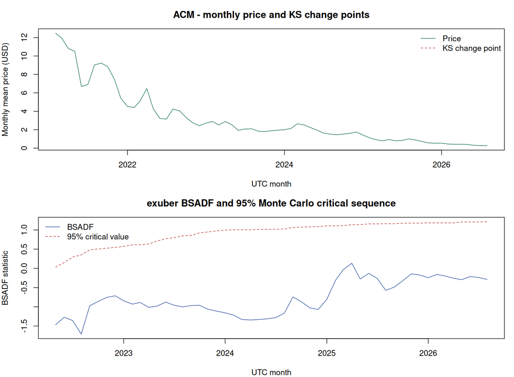

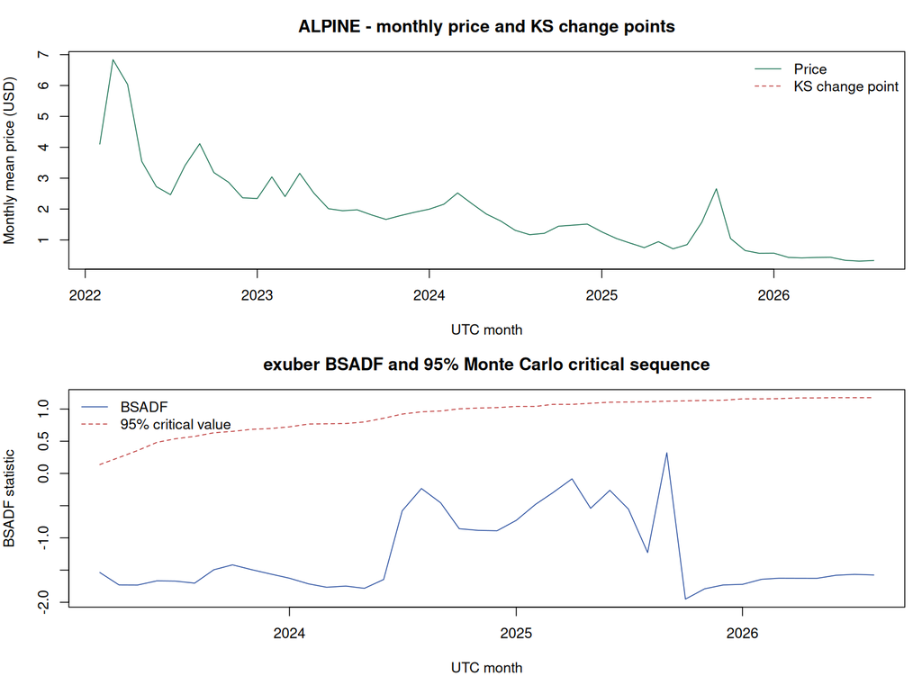

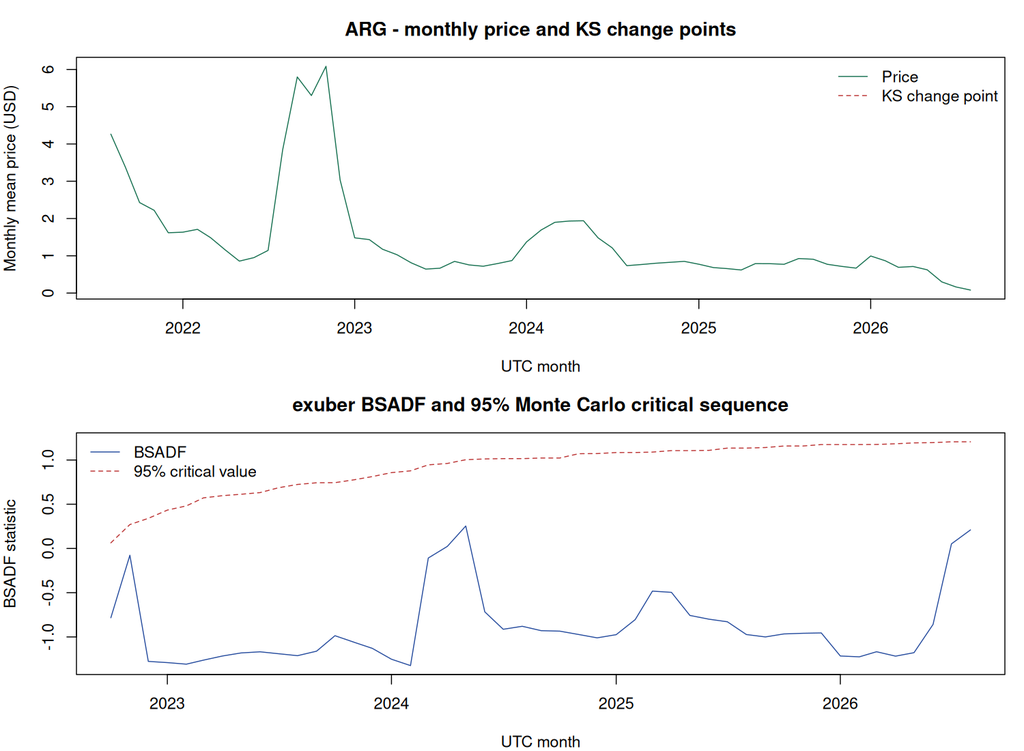

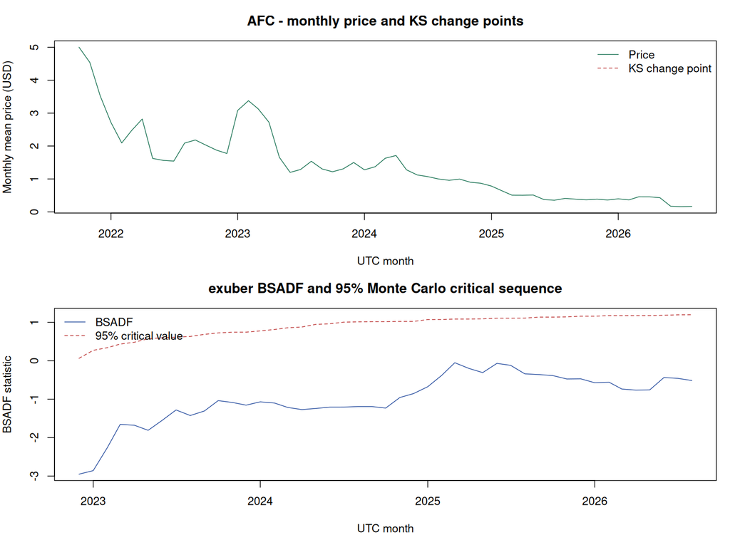

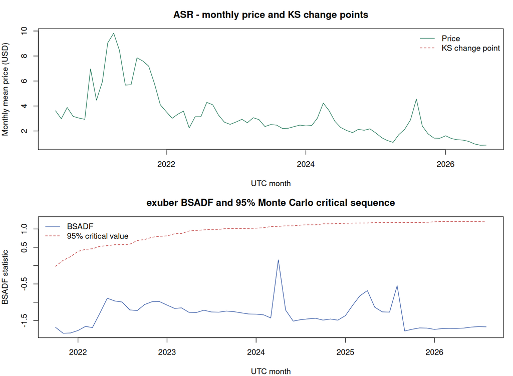

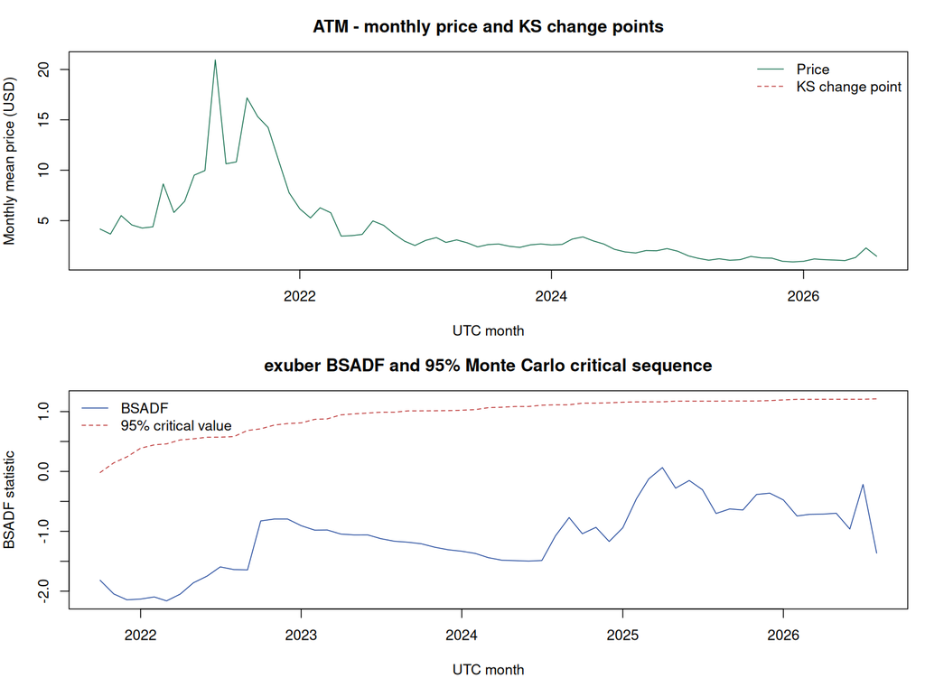

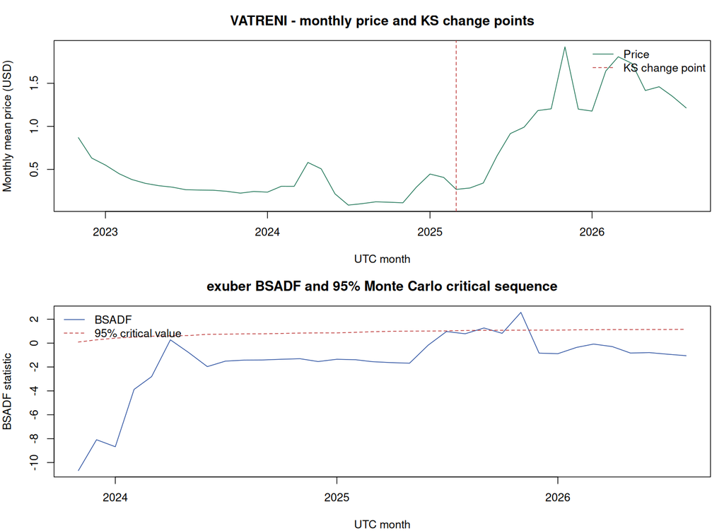

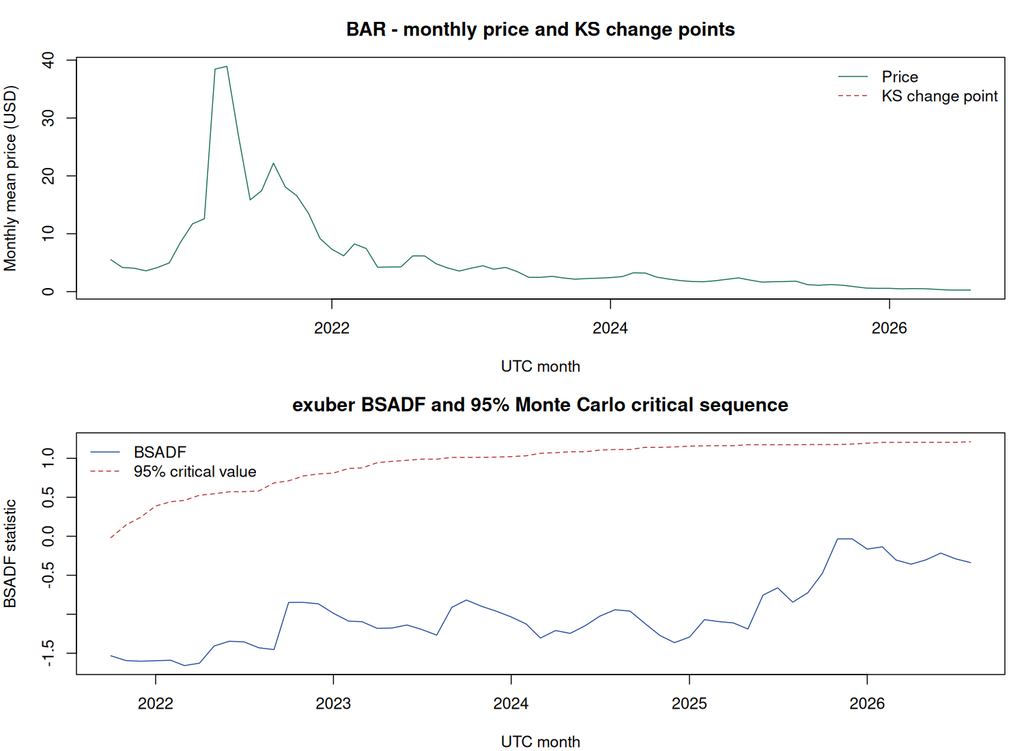

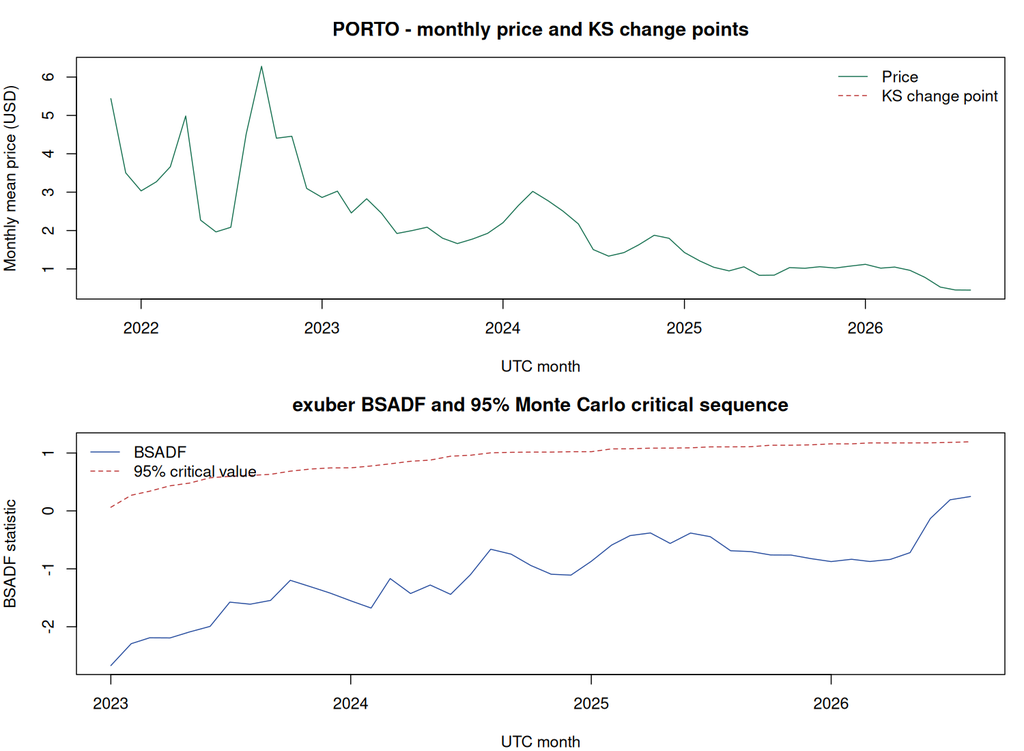

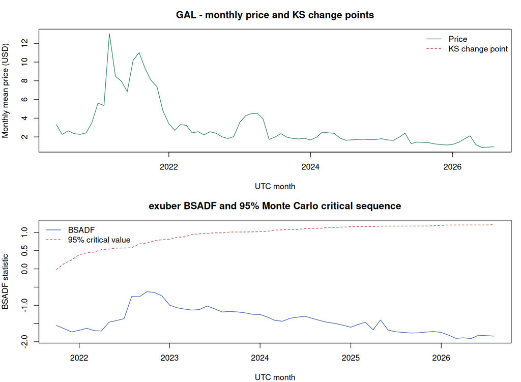

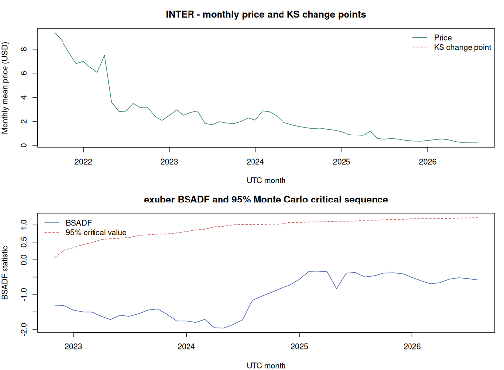

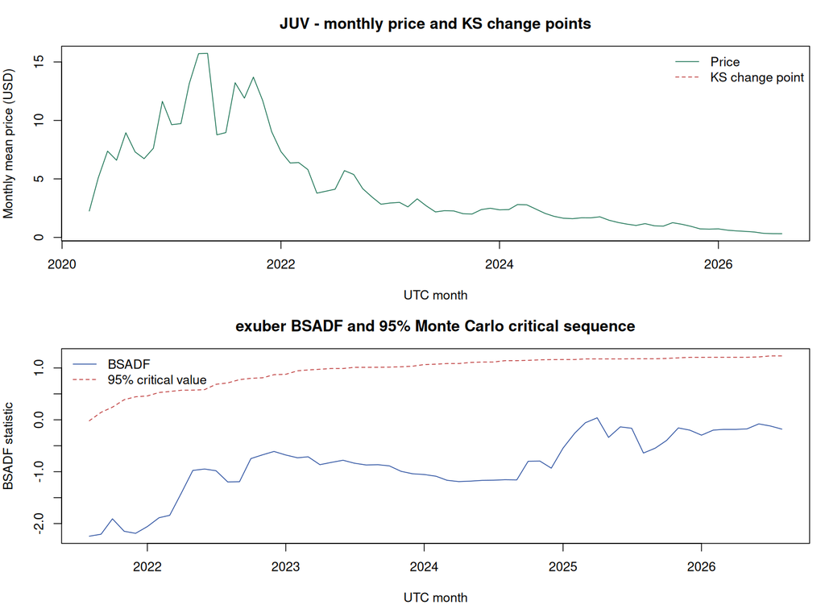

[8 more figures not shown]

KS distribution changes are statistical regimes. The paper’s green-energy phase labels are not transferred to fan tokens. BSADF euphoric episodes are distinct from complete formation, burst, and decline cycles.

# 4 Propagation phase

The available-data adaptation uses token, BTC, and CHZ price levels with `urca::ca.jo(type="trace", K=2, ecdet="none", spec="longrun")`. VECMs are fitted using `urca::cajorls()` only when the 5% sequential trace rule selects an intermediate rank. Unit-root diagnostics are supplied. A p=1 VAR and package Granger F-tests summarize benchmark predictability. These results concern a different variable system from the paper’s FSI/oil system and cannot support its financial-stress conclusion.

```r
run_propagation(data)
```

```r
knitr::kable(read_table("Results/benchmark_johansen_trace.csv"), digits = 4)
```

| asset_id | null_rank_at_most | trace_statistic | critical_5pct | reject_5pct | observations | variable_set |
| --- | --- | --- | --- | --- | --- | --- |
| ac-milan-fan-token | 0 | 49.6056 | 31.52 | TRUE | 67 | standardized token/BTC/CHZ price levels |
| ac-milan-fan-token | 1 | 14.6169 | 17.95 | FALSE | 67 | standardized token/BTC/CHZ price levels |
| ac-milan-fan-token | 2 | 1.7916 | 8.18 | FALSE | 67 | standardized token/BTC/CHZ price levels |
| alpine-f1-team-fan-token | 0 | 43.5111 | 31.52 | TRUE | 55 | standardized token/BTC/CHZ price levels |
| alpine-f1-team-fan-token | 1 | 11.4979 | 17.95 | FALSE | 55 | standardized token/BTC/CHZ price levels |
| alpine-f1-team-fan-token | 2 | 1.6820 | 8.18 | FALSE | 55 | standardized token/BTC/CHZ price levels |
| argentine-football-association-fan-token | 0 | 27.2284 | 31.52 | FALSE | 61 | standardized token/BTC/CHZ price levels |
| argentine-football-association-fan-token | 1 | 10.5419 | 17.95 | FALSE | 61 | standardized token/BTC/CHZ price levels |
| argentine-football-association-fan-token | 2 | 1.3160 | 8.18 | FALSE | 61 | standardized token/BTC/CHZ price levels |
| arsenal-fan-token | 0 | 50.2471 | 31.52 | TRUE | 59 | standardized token/BTC/CHZ price levels |
| arsenal-fan-token | 1 | 17.0115 | 17.95 | FALSE | 59 | standardized token/BTC/CHZ price levels |
| arsenal-fan-token | 2 | 1.6933 | 8.18 | FALSE | 59 | standardized token/BTC/CHZ price levels |
| as-roma-fan-token | 0 | 30.1836 | 31.52 | FALSE | 75 | standardized token/BTC/CHZ price levels |
| as-roma-fan-token | 1 | 11.5593 | 17.95 | FALSE | 75 | standardized token/BTC/CHZ price levels |
| as-roma-fan-token | 2 | 1.1706 | 8.18 | FALSE | 75 | standardized token/BTC/CHZ price levels |
| atletico-madrid | 0 | 31.4387 | 31.52 | FALSE | 75 | standardized token/BTC/CHZ price levels |
| atletico-madrid | 1 | 7.1632 | 17.95 | FALSE | 75 | standardized token/BTC/CHZ price levels |
| atletico-madrid | 2 | 1.0871 | 8.18 | FALSE | 75 | standardized token/BTC/CHZ price levels |
| croatian-ff-fan-token | 0 | 21.9978 | 31.52 | FALSE | 46 | standardized token/BTC/CHZ price levels |
| croatian-ff-fan-token | 1 | 12.2052 | 17.95 | FALSE | 46 | standardized token/BTC/CHZ price levels |
| croatian-ff-fan-token | 2 | 5.8048 | 8.18 | FALSE | 46 | standardized token/BTC/CHZ price levels |
| fc-barcelona-fan-token | 0 | 29.9495 | 31.52 | FALSE | 75 | standardized token/BTC/CHZ price levels |
| fc-barcelona-fan-token | 1 | 11.4248 | 17.95 | FALSE | 75 | standardized token/BTC/CHZ price levels |
| fc-barcelona-fan-token | 2 | 1.6338 | 8.18 | FALSE | 75 | standardized token/BTC/CHZ price levels |
| fc-porto | 0 | 69.3344 | 31.52 | TRUE | 58 | standardized token/BTC/CHZ price levels |
| fc-porto | 1 | 14.9634 | 17.95 | FALSE | 58 | standardized token/BTC/CHZ price levels |
| fc-porto | 2 | 1.2145 | 8.18 | FALSE | 58 | standardized token/BTC/CHZ price levels |
| galatasaray-fan-token | 0 | 27.7969 | 31.52 | FALSE | 75 | standardized token/BTC/CHZ price levels |
| galatasaray-fan-token | 1 | 5.9834 | 17.95 | FALSE | 75 | standardized token/BTC/CHZ price levels |
| galatasaray-fan-token | 2 | 1.0096 | 8.18 | FALSE | 75 | standardized token/BTC/CHZ price levels |
| inter-milan-fan-token | 0 | 37.1588 | 31.52 | TRUE | 60 | standardized token/BTC/CHZ price levels |
| inter-milan-fan-token | 1 | 16.4751 | 17.95 | FALSE | 60 | standardized token/BTC/CHZ price levels |
| inter-milan-fan-token | 2 | 1.6229 | 8.18 | FALSE | 60 | standardized token/BTC/CHZ price levels |
| juventus-fan-token | 0 | 26.8822 | 31.52 | FALSE | 77 | standardized token/BTC/CHZ price levels |
| juventus-fan-token | 1 | 6.9640 | 17.95 | FALSE | 77 | standardized token/BTC/CHZ price levels |
| juventus-fan-token | 2 | 1.1868 | 8.18 | FALSE | 77 | standardized token/BTC/CHZ price levels |
| lazio-fan-token | 0 | 39.8638 | 31.52 | TRUE | 59 | standardized token/BTC/CHZ price levels |
| lazio-fan-token | 1 | 17.0908 | 17.95 | FALSE | 59 | standardized token/BTC/CHZ price levels |
| lazio-fan-token | 2 | 1.7847 | 8.18 | FALSE | 59 | standardized token/BTC/CHZ price levels |
| manchester-city-fan-token | 0 | 27.1527 | 31.52 | FALSE | 64 | standardized token/BTC/CHZ price levels |
| manchester-city-fan-token | 1 | 5.7769 | 17.95 | FALSE | 64 | standardized token/BTC/CHZ price levels |
| manchester-city-fan-token | 2 | 1.3616 | 8.18 | FALSE | 64 | standardized token/BTC/CHZ price levels |
| napoli-fan-token | 0 | 31.8153 | 31.52 | TRUE | 48 | standardized token/BTC/CHZ price levels |
| napoli-fan-token | 1 | 15.3759 | 17.95 | FALSE | 48 | standardized token/BTC/CHZ price levels |
| napoli-fan-token | 2 | 4.1896 | 8.18 | FALSE | 48 | standardized token/BTC/CHZ price levels |
| og-fan-token | 0 | 37.7299 | 31.52 | TRUE | 75 | standardized token/BTC/CHZ price levels |
| og-fan-token | 1 | 12.2450 | 17.95 | FALSE | 75 | standardized token/BTC/CHZ price levels |
| og-fan-token | 2 | 1.3991 | 8.18 | FALSE | 75 | standardized token/BTC/CHZ price levels |
| paris-saint-germain-fan-token | 0 | 33.1963 | 31.52 | TRUE | 75 | standardized token/BTC/CHZ price levels |
| paris-saint-germain-fan-token | 1 | 11.6637 | 17.95 | FALSE | 75 | standardized token/BTC/CHZ price levels |
| paris-saint-germain-fan-token | 2 | 1.2570 | 8.18 | FALSE | 75 | standardized token/BTC/CHZ price levels |
| portugal-national-team-fan-token | 0 | 32.7123 | 31.52 | TRUE | 58 | standardized token/BTC/CHZ price levels |
| portugal-national-team-fan-token | 1 | 15.3651 | 17.95 | FALSE | 58 | standardized token/BTC/CHZ price levels |
| portugal-national-team-fan-token | 2 | 1.7366 | 8.18 | FALSE | 58 | standardized token/BTC/CHZ price levels |
| santos-fc-fan-token | 0 | 43.3430 | 31.52 | TRUE | 57 | standardized token/BTC/CHZ price levels |
| santos-fc-fan-token | 1 | 17.1078 | 17.95 | FALSE | 57 | standardized token/BTC/CHZ price levels |
| santos-fc-fan-token | 2 | 1.8444 | 8.18 | FALSE | 57 | standardized token/BTC/CHZ price levels |
| trabzonspor-fan-token | 0 | 32.2161 | 31.52 | TRUE | 70 | standardized token/BTC/CHZ price levels |
| trabzonspor-fan-token | 1 | 9.3590 | 17.95 | FALSE | 70 | standardized token/BTC/CHZ price levels |
| trabzonspor-fan-token | 2 | 0.7338 | 8.18 | FALSE | 70 | standardized token/BTC/CHZ price levels |

No fan-token Google Trends data or financial-stress series was supplied. Their status is recorded in `Results/paper_extension_status.csv`. Original green-energy search data remain in Original-paper as reference material, not fan-token sentiment.

# 5 Forecasting phase

The expanding-window exercise predicts one monthly observation at a time. `forecast::auto.arima(seasonal=FALSE)` and the original BSTS state specification are used. BSTS has 1,000 MCMC draws, seed 9, and 10% suggested burn-in. Holdout length is at most the paper’s 37 months; each series retains at least 36 training months because the fan-token histories are shorter than the paper’s sample.

The code also implements ARIMAX if an actual, complete fan-token search-interest input is later supplied. Current results contain the two available univariate baselines. The current-interest ARIMAX model is a conditional nowcast; it is not a forecast available before target-month search interest is observed.

```r
run_forecasting(data)
```

```r
knitr::kable(read_table("Results/forecast_accuracy.csv"), digits = 4)
```

| asset_id | model | forecasts | start_date | end_date | rmse_log_price | smape_log_price_pct | rmse_price_usd | smape_price_pct | interval_coverage |
| --- | --- | --- | --- | --- | --- | --- | --- | --- | --- |
| ac-milan-fan-token | ARIMA | 31 | 2024-02-01 | 2026-08-01 | 0.1342 | 42.3970 | 0.1862 | 11.0306 | 1.0000 |
| ac-milan-fan-token | BSTS | 31 | 2024-02-01 | 2026-08-01 | 0.2003 | 53.9782 | 0.2674 | 16.4669 | 0.9677 |
| alpine-f1-team-fan-token | ARIMA | 19 | 2025-02-01 | 2026-08-01 | 0.3378 | 81.6021 | 0.4969 | 23.8955 | 0.8421 |
| alpine-f1-team-fan-token | BSTS | 19 | 2025-02-01 | 2026-08-01 | 0.3888 | 94.6717 | 0.4790 | 32.9540 | 0.8947 |
| argentine-football-association-fan-token | ARIMA | 25 | 2024-08-01 | 2026-08-01 | 0.2570 | 62.4783 | 0.1598 | 17.9965 | 0.9200 |
| argentine-football-association-fan-token | BSTS | 25 | 2024-08-01 | 2026-08-01 | 0.4433 | 98.5292 | 0.3805 | 28.7251 | 0.8400 |
| arsenal-fan-token | ARIMA | 23 | 2024-10-01 | 2026-08-01 | 0.2284 | 33.4432 | 0.0834 | 13.8133 | 0.9565 |
| arsenal-fan-token | BSTS | 23 | 2024-10-01 | 2026-08-01 | 0.2617 | 58.4495 | 0.1339 | 20.4165 | 0.9565 |
| as-roma-fan-token | ARIMA | 37 | 2023-08-01 | 2026-08-01 | 0.2133 | 34.5477 | 0.5914 | 15.9242 | 0.9459 |
| as-roma-fan-token | BSTS | 37 | 2023-08-01 | 2026-08-01 | 0.2575 | 51.7290 | 0.5722 | 21.8609 | 1.0000 |
| atletico-madrid | ARIMA | 37 | 2023-08-01 | 2026-08-01 | 0.1744 | 50.1409 | 0.3107 | 13.1412 | 0.9730 |
| atletico-madrid | BSTS | 37 | 2023-08-01 | 2026-08-01 | 0.2374 | 53.8422 | 0.4874 | 16.6630 | 0.9459 |
| croatian-ff-fan-token | ARIMA | 10 | 2025-11-01 | 2026-08-01 | 0.3021 | 53.5675 | 0.4448 | 19.1471 | 0.9000 |
| croatian-ff-fan-token | BSTS | 10 | 2025-11-01 | 2026-08-01 | 0.3486 | 80.6257 | 0.4959 | 26.4389 | 1.0000 |
| fc-barcelona-fan-token | ARIMA | 37 | 2023-08-01 | 2026-08-01 | 0.1459 | 26.4095 | 0.2503 | 11.3584 | 1.0000 |
| fc-barcelona-fan-token | BSTS | 37 | 2023-08-01 | 2026-08-01 | 0.1946 | 34.1732 | 0.3476 | 15.9723 | 1.0000 |
| fc-porto | ARIMA | 22 | 2024-11-01 | 2026-08-01 | 0.1495 | 98.3381 | 0.1533 | 11.5900 | 1.0000 |
| fc-porto | BSTS | 22 | 2024-11-01 | 2026-08-01 | 0.2182 | 101.4304 | 0.2517 | 18.0572 | 1.0000 |
| galatasaray-fan-token | ARIMA | 37 | 2023-08-01 | 2026-08-01 | 0.1882 | 31.6308 | 0.3277 | 12.4569 | 0.9459 |
| galatasaray-fan-token | BSTS | 37 | 2023-08-01 | 2026-08-01 | 0.1846 | 36.0293 | 0.3339 | 13.8536 | 0.9730 |
| inter-milan-fan-token | ARIMA | 24 | 2024-09-01 | 2026-08-01 | 0.2220 | 39.1274 | 0.1621 | 15.1328 | 0.9167 |
| inter-milan-fan-token | BSTS | 24 | 2024-09-01 | 2026-08-01 | 0.2679 | 64.0970 | 0.2282 | 21.9958 | 0.8750 |
| juventus-fan-token | ARIMA | 37 | 2023-08-01 | 2026-08-01 | 0.1290 | 45.9911 | 0.1827 | 10.4531 | 1.0000 |
| juventus-fan-token | BSTS | 37 | 2023-08-01 | 2026-08-01 | 0.1755 | 48.9788 | 0.2846 | 14.1154 | 1.0000 |
| lazio-fan-token | ARIMA | 23 | 2024-10-01 | 2026-08-01 | 0.1324 | 80.8673 | 0.1428 | 10.9512 | 1.0000 |
| lazio-fan-token | BSTS | 23 | 2024-10-01 | 2026-08-01 | 0.1959 | 110.5016 | 0.1996 | 17.1117 | 1.0000 |
| manchester-city-fan-token | ARIMA | 28 | 2024-05-01 | 2026-08-01 | 0.1072 | 42.3544 | 0.1383 | 8.8253 | 1.0000 |
| manchester-city-fan-token | BSTS | 28 | 2024-05-01 | 2026-08-01 | 0.2246 | 65.5803 | 0.3644 | 17.3670 | 0.9643 |
| napoli-fan-token | ARIMA | 12 | 2025-09-01 | 2026-08-01 | 0.1583 | 14.8197 | 0.0666 | 12.8269 | 1.0000 |
| napoli-fan-token | BSTS | 12 | 2025-09-01 | 2026-08-01 | 0.2594 | 29.8627 | 0.1252 | 21.2319 | 1.0000 |
| og-fan-token | ARIMA | 37 | 2023-08-01 | 2026-08-01 | 0.2904 | 12.4504 | 2.3054 | 19.6913 | 0.9189 |
| og-fan-token | BSTS | 37 | 2023-08-01 | 2026-08-01 | 0.3297 | 15.3046 | 2.3662 | 23.5448 | 0.8919 |
| paris-saint-germain-fan-token | ARIMA | 37 | 2023-08-01 | 2026-08-01 | 0.1865 | 34.3998 | 0.4436 | 14.6193 | 0.9459 |
| paris-saint-germain-fan-token | BSTS | 37 | 2023-08-01 | 2026-08-01 | 0.2351 | 40.6572 | 0.6706 | 19.1951 | 1.0000 |
| portugal-national-team-fan-token | ARIMA | 22 | 2024-11-01 | 2026-08-01 | 0.2996 | 60.9467 | 0.1506 | 20.9961 | 0.9091 |
| portugal-national-team-fan-token | BSTS | 22 | 2024-11-01 | 2026-08-01 | 0.4056 | 89.2872 | 0.2058 | 29.8721 | 0.9091 |
| santos-fc-fan-token | ARIMA | 21 | 2024-12-01 | 2026-08-01 | 0.1962 | 39.0327 | 0.4300 | 16.0370 | 1.0000 |
| santos-fc-fan-token | BSTS | 21 | 2024-12-01 | 2026-08-01 | 0.3019 | 49.3253 | 0.6058 | 24.4761 | 0.9524 |
| trabzonspor-fan-token | ARIMA | 34 | 2023-11-01 | 2026-08-01 | 0.1446 | 54.6576 | 0.0857 | 12.2705 | 1.0000 |
| trabzonspor-fan-token | BSTS | 34 | 2023-11-01 | 2026-08-01 | 0.2152 | 74.5382 | 0.1637 | 18.2249 | 1.0000 |

Metrics are reported on both log-price and USD-price scales. Exponentiated log-point predictions are labeled median price forecasts. Diebold-Mariano tests use `multDM::DM.test()` and squared error; per-token model confidence sets use `MCS::MCSprocedure(alpha=0.15, B=5000, statistic="TR")`. Without search-interest data, the comparison set contains ARIMA and BSTS. No superiority of an unavailable ARIMAX model is asserted.

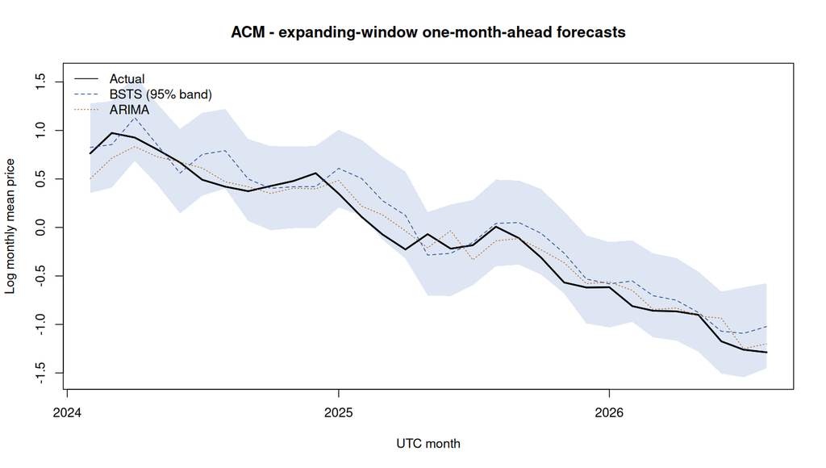

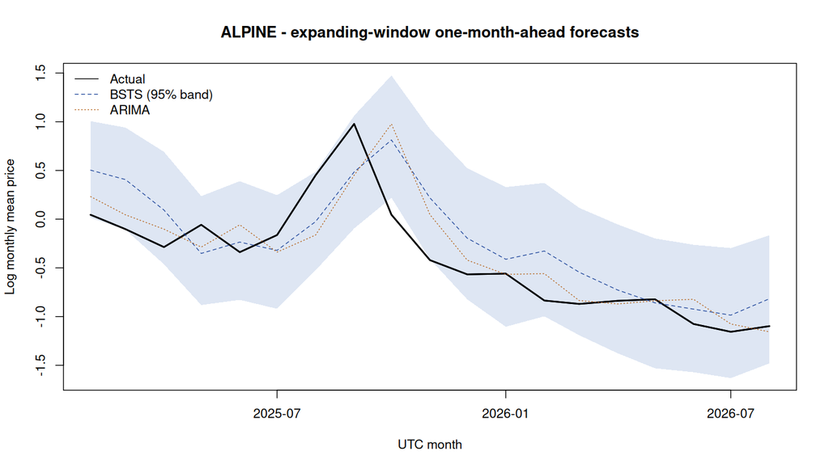

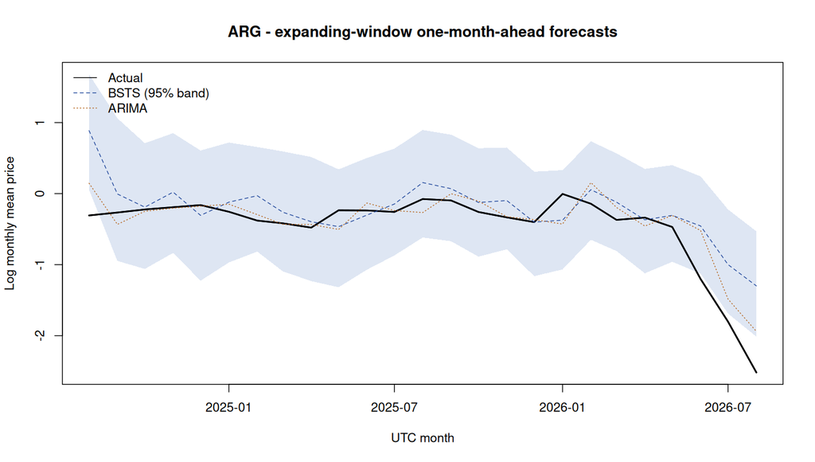

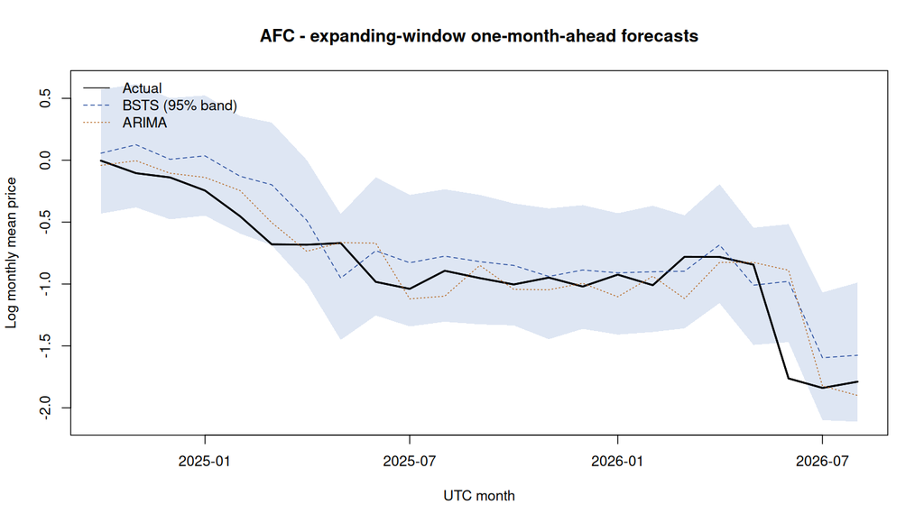

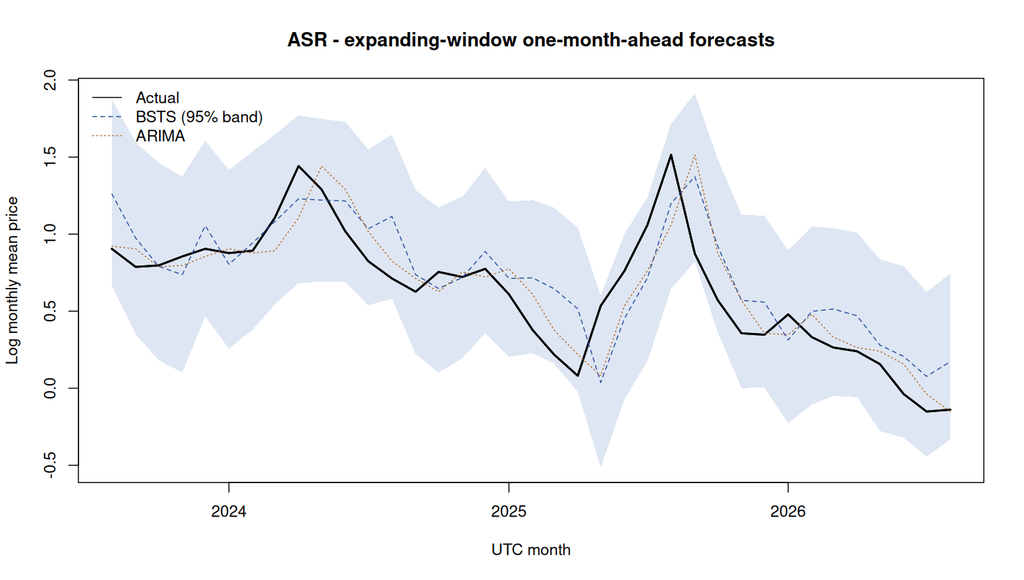

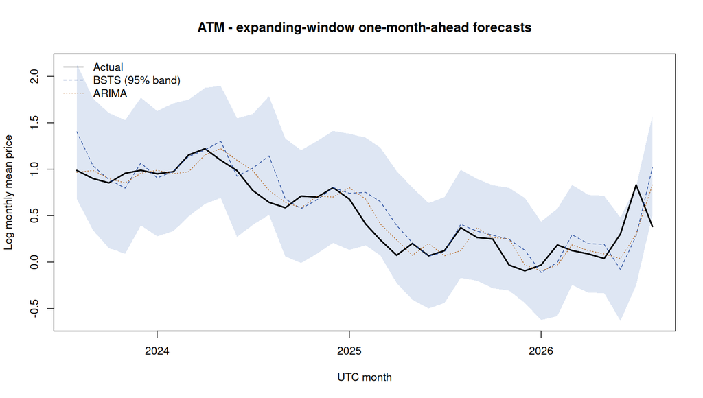

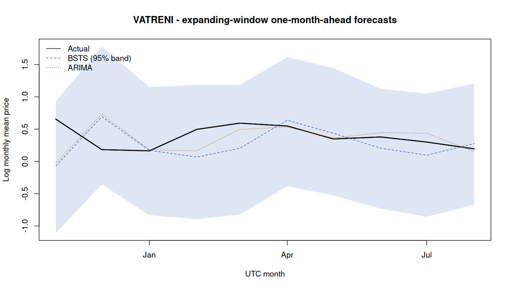

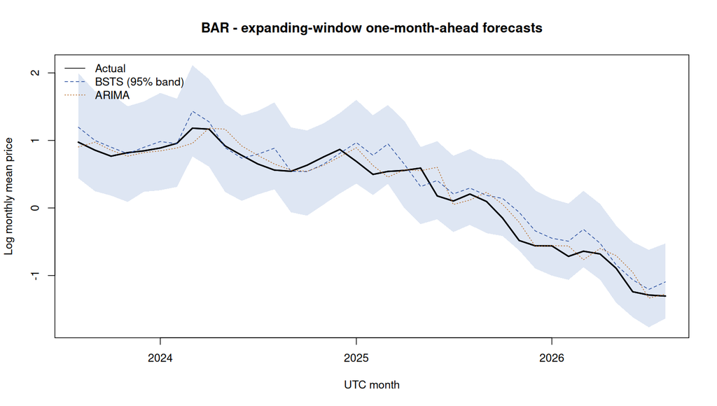

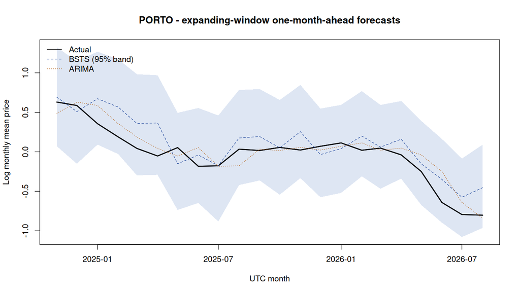

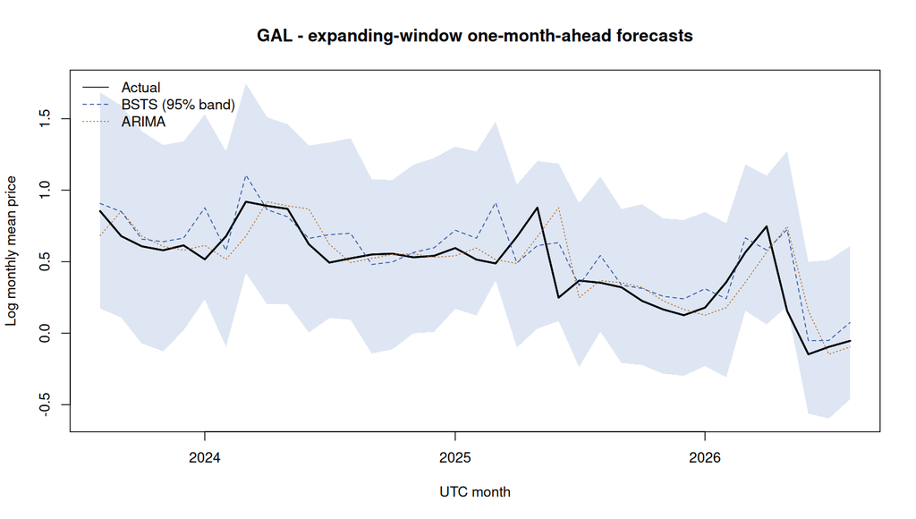

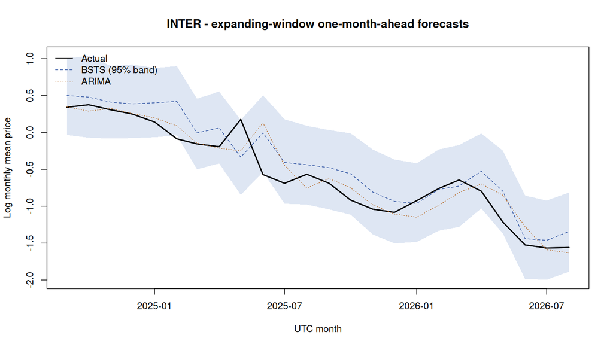

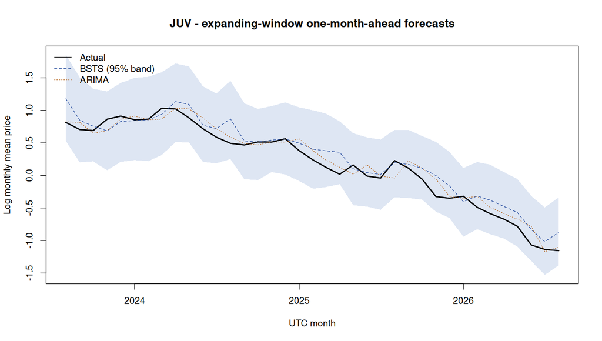

[8 more figures not shown]

# 6 Validation and reported results

```r
source("validate_paper_extensions.R")
write_report(data, started)
```

```
FAN-TOKEN R REPLICATION: GENERATED RESULTS

Generated (UTC): 2026-11-06 16:35:00 UTC
R: R version 4.5.2 (2025-10-31)
Elapsed minutes: 5.96

Frozen sample: 20 fan tokens and 3 benchmarks.
Daily calendar rows: 47558. Valid observed prices: 47558.
Daily cutoff: 2026-09-19 | Last complete modeled month: 2026-08-01
GSADF rejections at 95%: 2 of 20 eligible token blocks.
Package-dated 95% euphoric episodes: 3. Monthly KS change points: 1.
Forecasts per model: 553; token-specific holdouts range from 10 to 37 months.

Forecast accuracy (median across assets; log-price RMSE and USD-price SMAPE):
  ARIMA: median log RMSE 0.187385; median price SMAPE 13.477%
  BSTS: median log RMSE 0.247472; median price SMAPE 19.806%

INTERPRETATION AND LIMITS
BSADF identifies statistical explosiveness, not a complete economic bubble life cycle.
KS-CPM identifies distribution changes. Formation/burst/decline labels are not inferred automatically.
Shorter fan-token histories require rescaled startup and forecast training windows (see Methodology.txt).
Benchmark propagation uses BTC and CHZ, not the paper's financial-stress and oil variables.
Johansen/VECM tables are conditional diagnostics; consult the unit-root tests before interpreting cointegration.
No fan-token Google Trends or financial-stress dataset was supplied; affected paper claims remain unavailable.
The legacy Python analysis is archived for provenance and is not the source of these R statistics.
All numbers in this report are generated from the R result tables.

METHOD STATUS
                                       section                          status
                     Daily data reconstruction                       COMPLETED
                     Monthly exuber RADF/BSADF                       COMPLETED
                                Monthly KS-CPM                       COMPLETED
                      Weekly KS-CPM robustness                       COMPLETED
               Benchmark Johansen/VECM and VAR                       COMPLETED
               Expanding-window ARIMA and BSTS                       COMPLETED
 Search-interest ARIMAX and density comparison               UNAVAILABLE_INPUT
                  Financial-stress propagation               UNAVAILABLE_INPUT
                     Paper simulation appendix ORIGINAL_CODE_AND_DATA_INCLUDED
                                                                                                 detail
                                                            Rebuilt from archived provider JSON using R
                                                   Price levels; package Monte Carlo critical sequences
                                                     Nonparametric sequential distribution-change model
                                                                      Weekly mean prices with ARL0=5000
                                        Adapted token/BTC/CHZ system; does not measure financial stress
                                                  Paper package specifications and 1000 BSTS MCMC draws
                                  No fan-token Google Trends dataset supplied; no synthetic values used
                              No FSI series supplied; no market benchmark relabeled as financial stress
 Original-paper/Code-and-Data/Code.Rmd preserves the original appendix; not rerun for fan-token results

VALIDATION
1656 checks passed.
```

# 7 Simulation appendix

The paper’s original eGARCH bubble-generation and 1,000-replication simulation code is retained, unmodified, in `../Original-paper/Code-and-Data/Code.Rmd`. Those simulations assess the original paper’s methods; they are not empirical fan-token observations and are not counted among this project’s results.